# House EDA and Clean

Fiona R Lodge

January 6, 2019

## Loads

```r
library(tidyverse)
library(ggplot2)
set.seed(101)

estate <- read.csv('C:\\Users\\Owner\\Documents\\Securian interview\\real_estate_train.csv',
                   stringsAsFactors = F)
```

## Exploration of Missing Values

```r
num.nas <-
  estate %>%
  summarise_all(funs(sum(is.na(.)))) %>%
  select_if(. > 0) %>%
  gather(key = 'variable', value = 'missing.values') %>%
  arrange(desc(missing.values))

num.nas[1:10,]
```

```
##        variable missing.values
## 1        PoolQC           1453
## 2   MiscFeature           1406
## 3         Alley           1369
## 4         Fence           1179
## 5   FireplaceQu            690
## 6   LotFrontage            259
## 7    GarageType             81
## 8   GarageYrBlt             81
## 9  GarageFinish             81
## 10   GarageQual             81
```

The following information was gathered from the table above:

`PoolQC`, `MisFeature`, `Fence`, and `Alley` were removed for lack of distributed data in their categories.

This first round of mutations included attempts at mutating columns to make sense for the data. For example, an `NA` value in `BsmtQual` was assumed to mean that no basement existed, so `None` was assigned. See comments in the code below.

```r
estate2 <-
  estate %>%
  select(-PoolQC, -Fence, -MiscFeature, -Alley) %>%
  mutate(Electrical = if_else(is.na(Electrical), 'SBrkr', Electrical), # Almost all were SBrk
         MasVnrArea = if_else(is.na(MasVnrArea), as.integer(0), MasVnrArea)) %>% # Assumed no masonry area existed
  mutate_at(vars(MasVnrType, BsmtQual, BsmtCond, BsmtExposure, BsmtFinType1, BsmtFinType2, FireplaceQu, GarageType, GarageFinish,
                 GarageQual, GarageCond), funs(if_else(is.na(.), 'None', as.character(.)))) %>% # Assumed none of that type existed
  mutate_at(vars(starts_with('Year')), as.numeric) # Prepared as years for model matrix
```

`LotFrontage` was my next problem, and to avoid introducing bias I used the the correlated value of `LotArea` to estimate `LotFrontage`. Although in the end I took `LotFrontage` out, I still included the code here as I felt more comfortable with this as an imputation method.

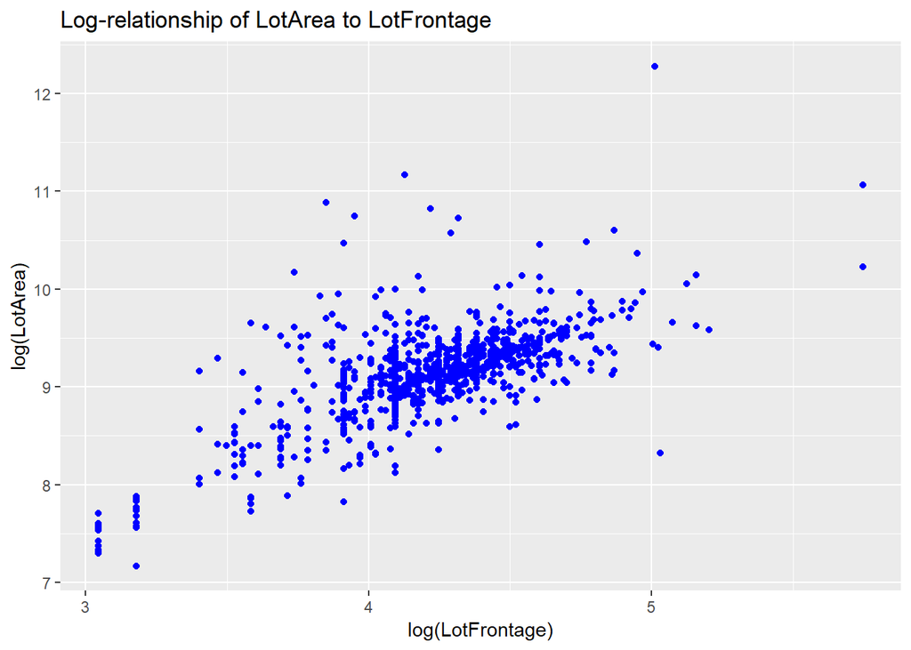

```r
estate2 %>%
  filter(!is.na(LotFrontage)) %>%
  ggplot(., aes(x = log(LotFrontage), y = log(LotArea))) + geom_point(color = 'blue') +
  ggtitle('Log-relationship of LotArea to LotFrontage')
```

```r
# Code to fill in values via linear model -- not run
# model.lotfrontage <- lm(log(num.vars$LotFrontage)~ log(num.vars$LotArea))
# slope <- as.numeric(model.lotfrontage$coefficients[2])
# intercept <- as.numeric(model.lotfrontage$coefficients[1])

estate3 <-
  estate2 %>%
  # mutate(LotFrontage = if_else(is.na(LotFrontage), as.integer(exp(slope*log(LotArea) + intercept)), LotFrontage))
  select(-LotFrontage)
```

## Exploration of Numerical Values

### Binary Changes

Some of the variables had distributions that looked similiar to the one below.

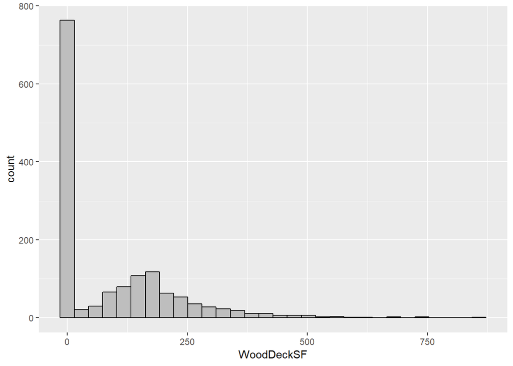

```r
estate3 %>%
  select(WoodDeckSF) %>%
  ggplot(., aes(x = WoodDeckSF)) +
  geom_histogram(fill = 'gray', color = 'black')
```

To fit these variables to a better distribution, I changed them to be binary. For example the WoodDeckSF was changed so that the variable represented whether or not the house had a wood deck or not. Several others were transformed in this manner;

Transformed to binary: `X2ndFlrSF`, `Fireplaces`, `HalfBath`, `BsmtFullBath`.

See the adjusted distribution for for the `WoodDeckSF` variable.

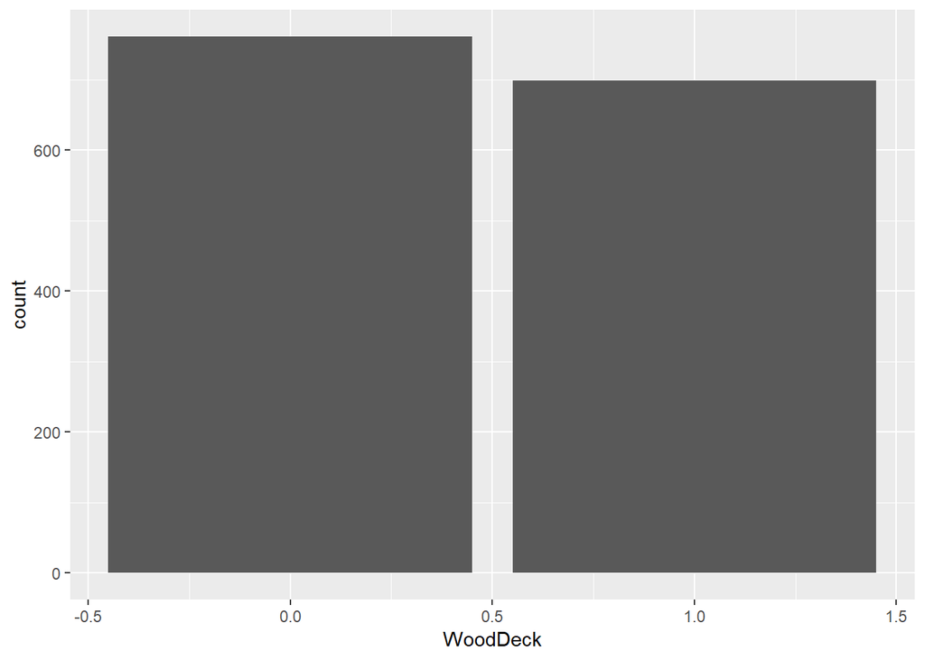

```r
estate3 %>%
  select(WoodDeckSF) %>%
  mutate(WoodDeck = if_else(WoodDeckSF > 0, as.integer(1), as.integer(0))) %>%
  ggplot(., aes(x = WoodDeck)) +
  geom_bar()
```

Below are the other transformations I arrived at for the numerical variables:

```r
estate3.5 <-
  estate3 %>%
  # mutate_at(vars(SalePrice, LotArea, GrLivArea, X1stFlrSF, TotalBsmtSF, OpenPorchSF), funs(log(. + 1))) %>%
  # mutate(BsmtUnfSF = sqrt(BsmtUnfSF)) %>%
  mutate(WoodDeck = if_else(WoodDeckSF > 0, as.integer(1), as.integer(0)),
         Fireplaces = if_else(Fireplaces > 0, as.integer(1), as.integer(0)),
         HalfBath = if_else(HalfBath > 0, as.integer(1), as.integer(0)),
         BsmtFullBath = if_else(BsmtFullBath > 0, as.integer(1), as.integer(0)),
         X2ndFlrSF = if_else(X2ndFlrSF > 0, as.integer(1), as.integer(0))) %>%
  mutate(PorchOpen =
           case_when(OpenPorchSF > 0 ~ 'open',
                     EnclosedPorch > 0 ~ 'Enclosed',
                     TRUE ~ 'None'),
         PorchTypeScreen =
           case_when(X3SsnPorch > 0 ~ 'X3Ssn',
                     ScreenPorch > 0 ~ 'Screen',
                     TRUE ~ 'None')) %>% # This didn't help, remove it
  dplyr::select(-PorchTypeScreen, -X3SsnPorch, -ScreenPorch, -PoolArea, -KitchenAbvGr,
         -BsmtHalfBath, -MiscVal, -LowQualFinSF, -WoodDeckSF, -OpenPorchSF, -EnclosedPorch, -X2ndFlrSF, -X1stFlrSF, -GarageYrBlt, -Electrical) #Not sure about GarageYrBlt  , -GarageYrBlt, -GarageCars
```

## Exploration of Categorical Values

This same process was applied to the categorical values, but I installed some metrics:

1. If a category of a group had more than 85% of the data in it, this group was marked for removal.
2. If the ratio of the largest category to the second largest category was greater than 20, this group was removed.

```r
thresh.pct <- 0.85

cat.vars <-
  estate3.5 %>%
  select_if(is.character)

cat.vars.toremove <-
  cat.vars %>%
  gather(key = 'columns') %>%
  group_by(columns, value) %>%
  summarize(sums = n()) %>%
  arrange(desc(sums), .by_group = TRUE) %>%
  mutate(first.to.second = if_else(sums[1]/sums[2] > 20, 'remove', 'keep')) %>%
  ungroup %>%
  group_by(columns) %>%
  mutate(tmp_bool = if_else(any(sums > thresh.pct * nrow(cat.vars)), 'remove1', 'keep1')) %>%
  filter(tmp_bool == 'remove1' | first.to.second == 'remove') %>%
  ungroup %>%
  distinct(columns)

vec <- unlist(cat.vars.toremove$columns)
```

### Form the final dataset and model matrix

### Transformations

The method I am employing for modelling requires data to be all on the same plaing field, so I standardized all numerical categories.

```r
scale_this <- function(x){
  (x - mean(x, na.rm=TRUE)) / sd(x, na.rm=TRUE)
}

estate4 <-
  estate3.5 %>%
  select(-one_of(vec)) %>%
  mutate(Id = as.character(Id)) %>%
  mutate_if(is.numeric, funs(scale_this(.))) %>%
  mutate(Id = as.numeric(Id))


library(glmnet)
mat = model.matrix( ~.-1, data = estate4)

write.csv(mat, 'C:\\Users\\Owner\\Documents\\Securian interview\\Interview2\\mod_mat.csv')
```

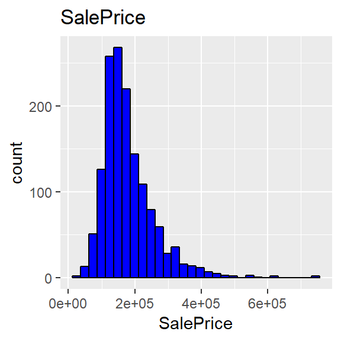

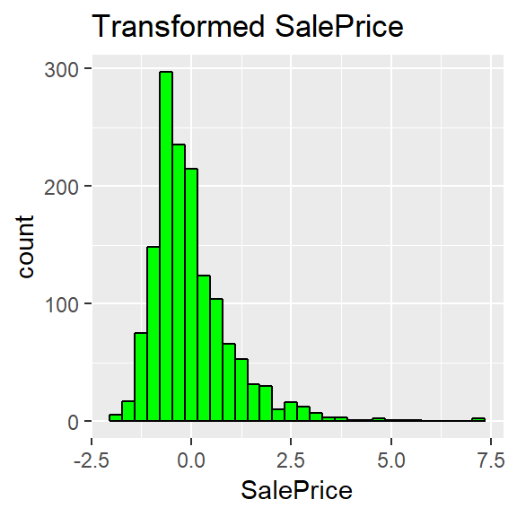

```r
estate3.5%>%
  select(SalePrice) %>%
  ggplot(aes(x = SalePrice)) +
  geom_histogram(fill = 'blue', color = 'black') +
  ggtitle('SalePrice')

estate4 %>%
  select(SalePrice) %>%
  ggplot(aes(x = SalePrice)) +
  geom_histogram(fill = 'green', color = 'black') +
  ggtitle('Transformed SalePrice')
```

### Observations of correlation/relationship to sale price

It may have behoved me to build a model from the ground up, as some variables appeared to correlate to `SalePrice`.

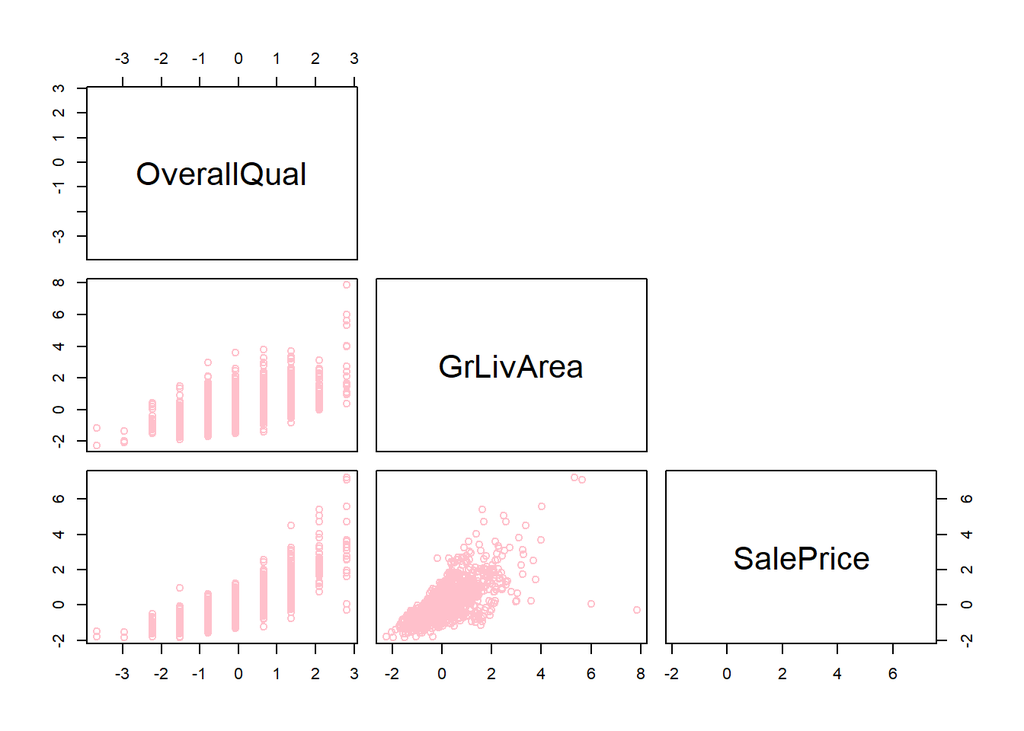

```r
cor.vars <-
  estate4 %>%
  select_if(is.numeric) %>%
  select(OverallQual, GrLivArea, SalePrice)
pairs(cor.vars, upper.panel = NULL, col = 'pink')
```

### View of some categorical values

The same is true of some categorical variables, such as neighborhood.

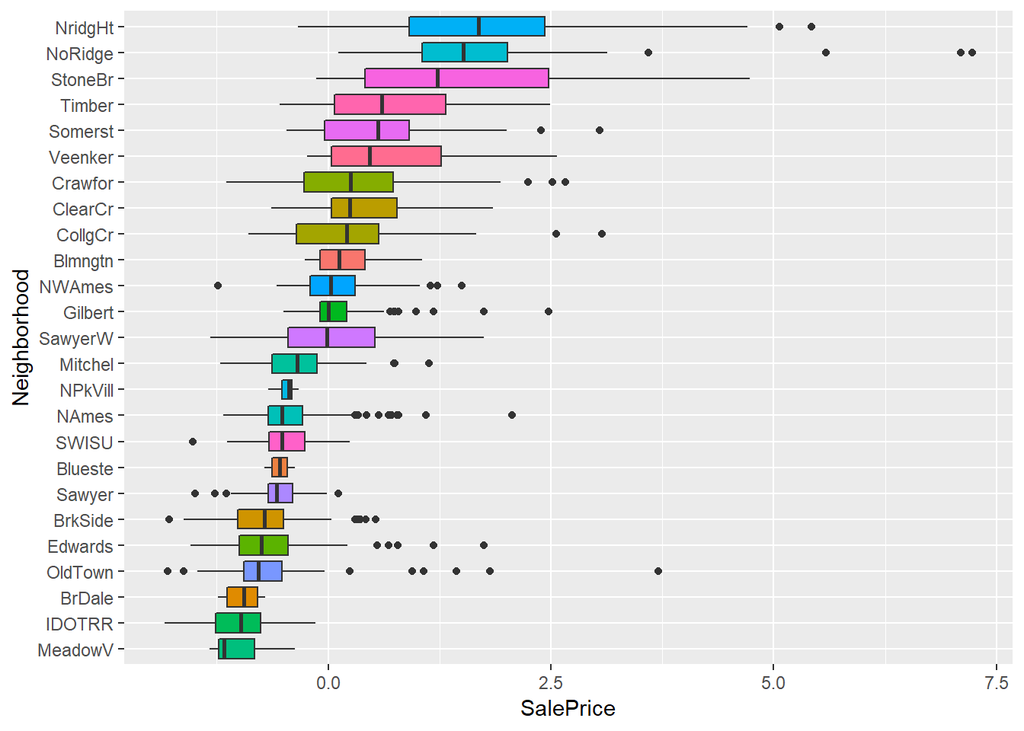

```r
estate4 %>%
  ggplot(aes(x = reorder(Neighborhood, SalePrice, FUN = median), y = SalePrice, fill = Neighborhood)) +
  geom_boxplot() +
  xlab('Neighborhood')+
  coord_flip() +
  theme(legend.position="none")
```